# Nomes: Andreza Barros

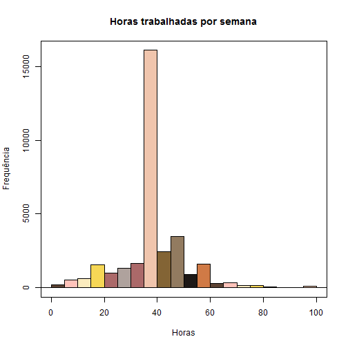

**Gráfico 9**. Quantidade de trabalho em horas por semana.

[figure not shown]

**Gráfico 10**. Distribuição da população de acordo com o sexo e o IMC.

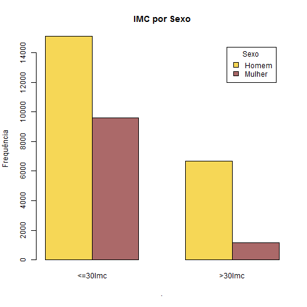

**Gráfico 11**. Boxplot do IMC de acordo com as horas trabalhadas por semana.

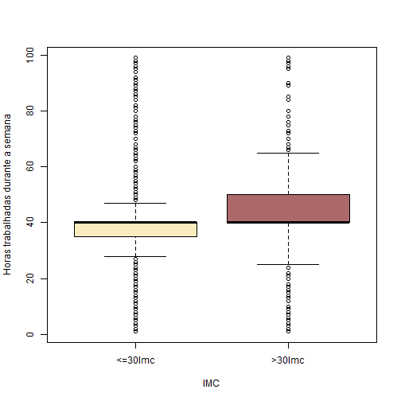

**Gráfico 12**. Boxplot da relação do salário em um ano e o IMC do cidadão.

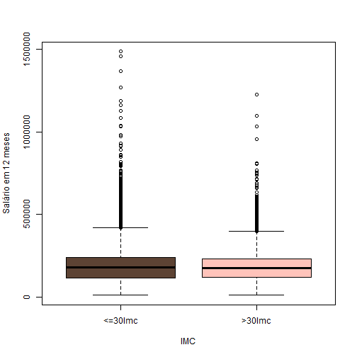

**Gráfico 13**. Demonstração gráfica das variáveis tempo de estudo em anos e IMC.

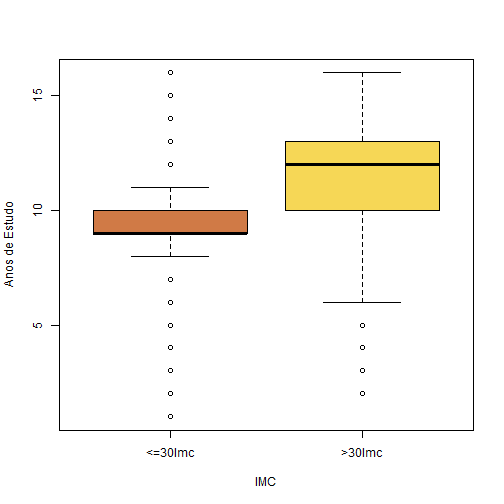

**Gráfico 14**. Mostra do perfil em relação à idade de acordo com IMC.

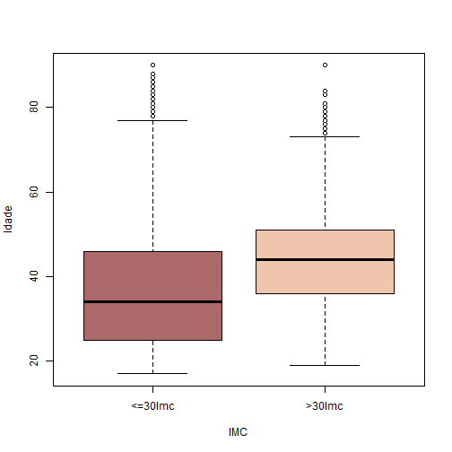

**Gráfico 15**. Relação do estado civil com o IMC.

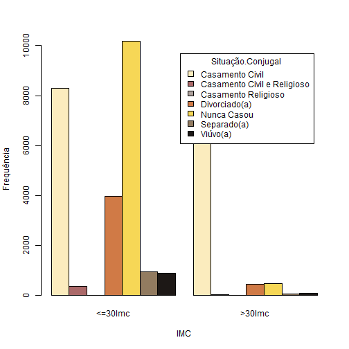

**Gráfico 16**. Caracterização de acordo com raça e IMC.

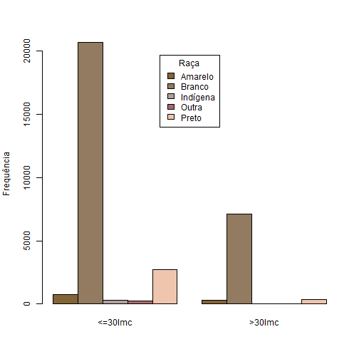

## Discussão

Vimos por meio destes gráficos e tabelas que a maioria da população é de homens brancos casados no civil com IMC considerado saudável. Que trabalham na empresa privada, estudaram entre 8 e 10 anos, trabalham de 30 ? 40 h por semana, ganhando entre 100 e 200 mil reais por ano.

Analisando a população que tem IMC acima do considerado seguro em relação à saúde nutricional, a maioria encontrada foi de homens brancos que trabalham entre 35 e 50 h por semana tendo de 10 a 15 anos de estudo e na faixa etária de 35 a 55 anos, casados apenas no civil.